# Computing a system's characteristic from a set of observations

Physics Labs in R

Prepared by Dmitry Gorodnichy for [R Ottawa](https://ivi-m.github.io/R-Ottawa/101.html)

December 2020

## Introduction

One of distinctive abilities of homo sapiens that distinquishes them from animals is the ability to think analytically. - We can make conclusions about *something that we do not see* from other *things that we can see* - and we do it all the time, either intuitively or using scientific methods. Here we'll talk about how to do scientifically - using physics and data science in R.

### Physics part

to measure a system's charactestic that cannot be measured directly from other charactestics that can be measured directly is one of the most common tasks in physics (as it in our life!). Examples are:

1. Finding how fast your child (or mushroom) grows (or bicycle moves), knowing that $V = displacement / time$.
2. Finding a force $F$ that was applied to an object of mass $m$ to move it with acceleration $a$, knowing that $F = m * a$ .
3. Finding the speed of a soccer ball (or a missile), knowing the angle at which it was kicked (launched) and the distance how far it flew: $V0 = \sqrt { g * distance \over sin2\beta})$.

Mathematically speaking (or, as scientists say, "mathematically formalized")", all of these tasks are the same, described as follows:

*Given*: a set of observations $(x_i, y_i), i \in \{1, ..., N\}$ and the relationship that links the output (reponse) variable $y$ to the input (trigger or factor) variable $y_i =k * x_i $, *Find*: $K$, or more specicifally, *Find*: $K$ such that *explains the best* the observed data, (Or, as scientists again would say) *Find*: $K$ such that produces the least total (or average) error between the actual $Y_i$ and expected $Y_i^*$ observations: $\sum_i^N(Y_i - Y_i^*)$.

Below we show how this can be done.

### Data science part

Actually, there is not such science as "data science" :) . The term was coined only the second decade of XXI-st century, whereas people worked with data since a several centuries before.

There are however many other types of science that work with data: Natural sciences (...), Social Sciences (...)

And then there is a special type of "science", which is not even part of Science schools in many universities (e.g. at uOttawa), but put of Engineering school - called "Computer science" or "Computing science". These are people who developed computer languages, complex algorithms, computer systems and programs, including the now a very notorious thing called "Artificial Intelligence" :)

We'll talk more about that later.

In meanwhile, go a head just download the source of this file: https://ivi-m.github.io/R-Ottawa/physics-labs/01_y=kx.Rmd.

Open it in R Studio, run it, and voila ! - You have built a "computer system"" that is doing a job for you already - loading data, computing formulas, and showing this article with results and comments!

Then, if you wish, you can save your result - the created .html file, and email it to your friend or publish on your personal page (e.g. in github) or RPubs - which is what we did with this article.

### R part

This article in R Markdown (.Rmd file) with a) bits of LaTex code for writting mathematical formula, and b) bits (or chunks, since there rather big bits) of R code

This is a scientific way of writting any article...

## Warm-up excercises

Prior to building solutions to the physics problems using R, let's set the foundation for what is called "robust scalable programming" in R.

### Key R concepts

R is the language that your computer understands So you need to translate your human language Click on the tab at right see how to write the R code. Click on [Code] buttons to see the codes for everything that iscomputer generatedin this article.

### Your first ever code in R to describes a physical system

```r
# Warm up exercise to help you to write your first R code:
# Experiment 1: trajectory of a ball kicked  by soccer player

# These are three MOST needed libraries:

library(magrittr);  # to chain :  1:10 %>% sin %>% round (2)  instead of  round(sin(1:10), 2)
library(data.table);# to use tables: dt <- data.table(x=1:10)  %>% .[, y:= sin(x) %>% round(2)]
library(ggplot2);   # to plot: ggplot(dt) + geom_line(aes(x,y))

# These are constants
g <-  9.8 # m/s^2

# These are variables and their values.
# NB: How we name variables and functions! Unless they are obvious (or used once only), they should be named in "hungarian" notation as shown below.

# Simple variable:

time_start <- 0   # time you start / finish observing (secs). It is numeric (i.e. floating point) number
time_end <- 3         # Better name :  fTimeEnd
nObservations <- 5L  # number of observations (inter). It is integer number.

# Array of simple variables:

# aObservations <- 0:nObservations;
aTimes <- seq(time_start, time_end, (time_end-time_start)/nObservations); aTimes # Better name: afTimes
```

```
## [1] 0.0 0.6 1.2 1.8 2.4 3.0
```

```r
aTimes %>% length()
```

```
## [1] 6
```

```r
V0 <- 30 # initial ball speed: min/sec
alpha <- 45 * pi / 180 # angle over horizon: degrees converted to radians
h0 <- 0 #initial heiaght: meter

# This is a function
mps2kmph <- function (speed){  # Another good name:  convertMinPerSec2KmPerHour()
  speed * ( 1 / 1000) / (1 / 3600);  # 1 km = 1000 m; 1 h = 3600
}
mps2kmph(V0)
```

```
## [1] 108
```

```r
# Complex variable: data.table (also known as "improved data.frame"")
# NB: Complex variable describes a complex system. - Each row represents a system state at time t

dtKickedBall <- data.table(t = aTimes);
dtKickedBall %>%
  .[, observation := 1:.N] %>%
  .[, ':='(
    x = V0 * cos(alpha) * t,
    y = h0 + V0 * sin(alpha) * t - g * t^2 / 2
    # Vx = V0 * cos(alpha),
    # Vy = V0 * sin(alpha) - g * t
  ) ]
# NB 1: There's no assignment operator ' <- ' ! New columns are added to existing data.table !
# NB 2: Note use of piping and multiple (vs. single) column modification
# NB 3: columns names in data.table do not need  follow naming conventions - you  print them anyway
dtKickedBall
```

```
##      t observation        x        y
## 1: 0.0           1  0.00000  0.00000
## 2: 0.6           2 12.72792 10.96392
## 3: 1.2           3 25.45584 18.39984
## 4: 1.8           4 38.18377 22.30777
## 5: 2.4           5 50.91169 22.68769
## 6: 3.0           6 63.63961 19.53961
```

```r
# Now we can find somethin  interesting in the dynamics of this system:

dtKickedBall[, c("t","y")] # show ("select", extract, or subset vertically)  data
```

```
##      t        y
## 1: 0.0  0.00000
## 2: 0.6 10.96392
## 3: 1.2 18.39984
## 4: 1.8 22.30777
## 5: 2.4 22.68769
## 6: 3.0 19.53961
```

```r
# dtKickedBall[, c(1,4)]   # the same
# dtKickedBall[, .(t,y)]   # the same

# dtKickedBall$y       # show ("pull", extract)  column as array
dtKickedBall[["y"]]  # the same
```

```
## [1]  0.00000 10.96392 18.39984 22.30777 22.68769 19.53961
```

```r
# dtKickedBall[2] # show the state at second row
dtKickedBall[c(1:2,(.N-2):.N)] # show ("slice", subset horisontally) the first and last two rows
```

```
##      t observation        x        y
## 1: 0.0           1  0.00000  0.00000
## 2: 0.6           2 12.72792 10.96392
## 3: 1.8           4 38.18377 22.30777
## 4: 2.4           5 50.91169 22.68769
## 5: 3.0           6 63.63961 19.53961
```

```r
dtKickedBall[y>0] # show ("filter") all states above the ground
```

```
##      t observation        x        y
## 1: 0.6           2 12.72792 10.96392
## 2: 1.2           3 25.45584 18.39984
## 3: 1.8           4 38.18377 22.30777
## 4: 2.4           5 50.91169 22.68769
## 5: 3.0           6 63.63961 19.53961
```

```r
dtKickedBall[which.max(y)] # show the state when the ball is observed at heighest point
```

```
##      t observation        x        y
## 1: 2.4           5 50.91169 22.68769
```

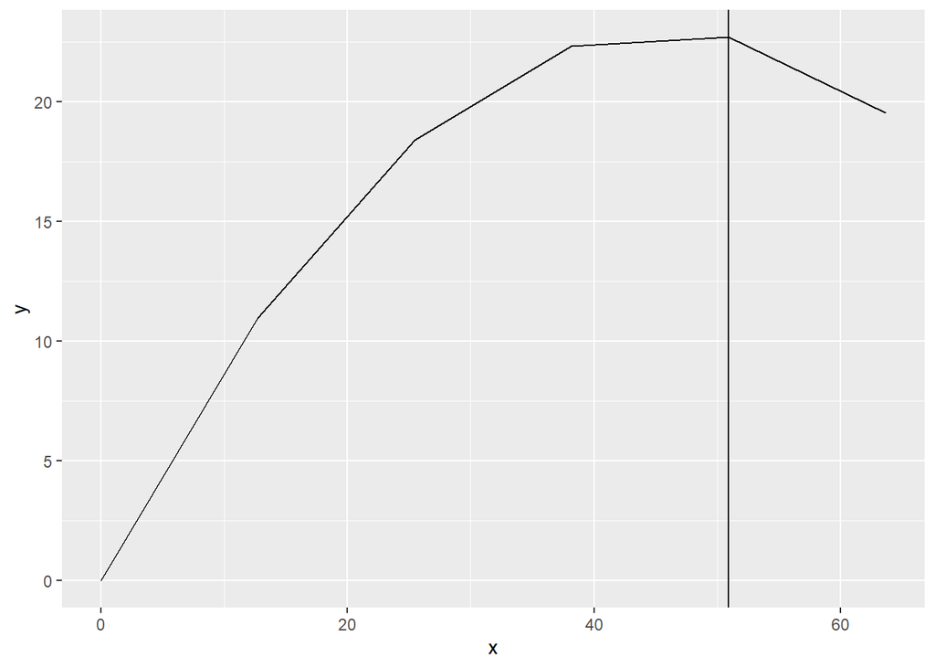

```r
# dtKickedBall[which.min(abs(Vy))] # ... when the ball started to descend - the same as above


# ... and plot the result
ggplot (dtKickedBall) +
  geom_line(aes(x,y)) +
  geom_vline(xintercept =dtKickedBall[which.max(y)]$x)
```

```r
# NB: use of "aes()" for plotting dtKickedBall$x and dtKickedBall$y


# FINAL step:
# Want to plot with different settings ? -
# Encapsulate everything above in a function that depends on the variables you want to change

fKickedBall <- function(time_start, time_end, nObservations, V0, alpha, h0) {
  # NB: to print anything (x) from inside a function, you need to use `x %>% print()`
}

# To learn more, goto: https://github.com/IVI-M/R-Ottawa/blob/master/resources.md
```

## Example 1: V = km / hour

Lets say, we made 5 measurements ("km" and "hour") for a moving object. The first step in any analysis is plotting the measurements:

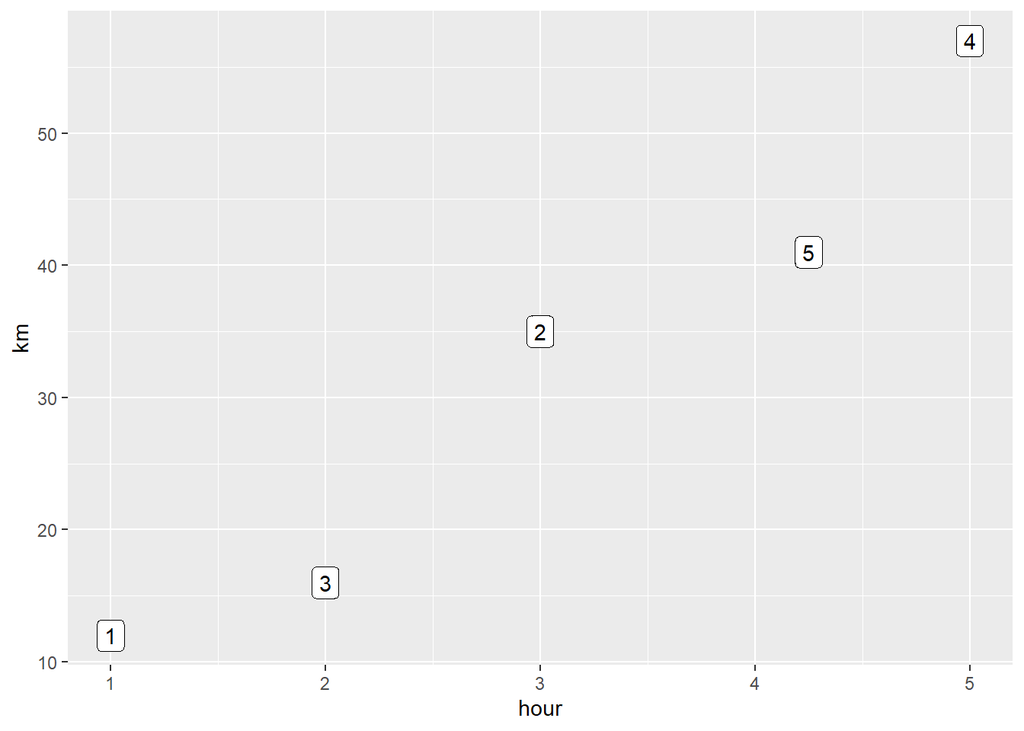

```r
library(data.table);
library(magrittr);
hour <- c(1,  3,  2, 5, 4.25)
km <- c(12, 35, 16, 57, 41)
dt <- data.table(km=km, hour=hour)


dt[, observation:=1:.N]

ggplot(dt) +  geom_label(aes(hour,km, label=observation))
```

One way of computing the object speed is to compute $V_i$ as $V=km_i/hour_i$ for each measurement and then take the average of it:

```r
dt$V <- round( dt$km / dt$hour, 1)
# dt %>% kable()
dt
```

```
##    km hour observation    V
## 1: 12 1.00           1 12.0
## 2: 35 3.00           2 11.7
## 3: 16 2.00           3  8.0
## 4: 57 5.00           4 11.4
## 5: 41 4.25           5  9.6
```

```r
V.ave1 = mean(dt$V) %>% round(1); V.ave1
```

```
## [1] 10.5
```

```r
V.sd1 = sd(dt$V) %>% round(1); V.sd1
```

```
## [1] 1.7
```

This gives us $V_{ave} = 10.5 \pm 1.7$

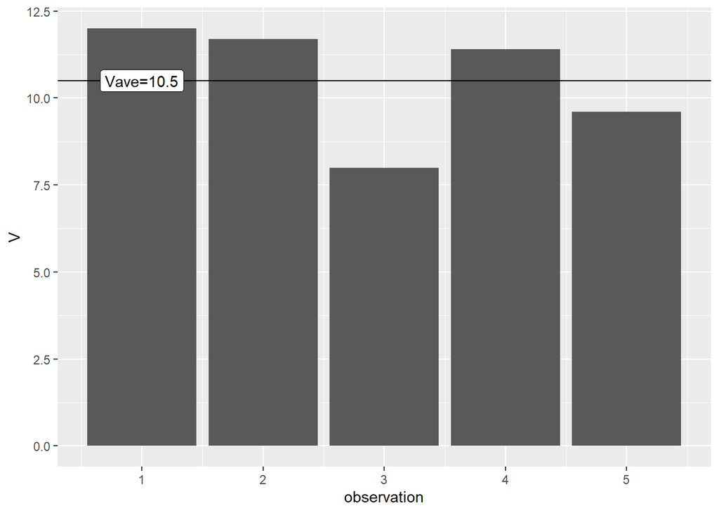

```r
ggplot(dt) + geom_col( aes(observation,V) ) +
  geom_hline(yintercept = V.ave1) +
  geom_label(aes(1,V.ave1,label=paste0("Vave=", V.ave1)))
```

This was easy enough and can be computed without any computer software!

Yet there's also another way to find V that is "mathematically more precise" but which cannot be done without a computer - it's called regression or building a linear model!

```r
# dt <- dt %>% rbind( data.table(0,0,0,0),use.names=FALSE )
# V.ave1 = mean(dt$V) %>% round(1); V.ave1
# V.sd1 = sd(dt$V) %>% round(1); V.sd1
# dt[, observation := 1:.N]

# https://rpubs.com/aaronsc32/regression-through-the-origin

model0 <- lm( dt$km  ~ 0 + dt$hour ) %T>% print # # Adding the 0 term tells the lm() to fit the line through the origin
```

```
##
## Call:
## lm(formula = dt$km ~ 0 + dt$hour)
##
## Coefficients:
## dt$hour
##   10.66
```

```r
str(model0);
```

[output not shown]

```r
summary(model0)
```

```
##
## Call:
## lm(formula = dt$km ~ 0 + dt$hour)
##
## Residuals:
##      1      2      3      4      5
##  1.341  3.022 -5.319  3.703 -4.302
##
## Coefficients:
##         Estimate Std. Error t value Pr(>|t|)
## dt$hour  10.6594     0.5595   19.05 4.47e-05 ***
## ---
## Signif. codes:  0 '***' 0.001 '**' 0.01 '*' 0.05 '.' 0.1 ' ' 1
##
## Residual standard error: 4.226 on 4 degrees of freedom
## Multiple R-squared:  0.9891, Adjusted R-squared:  0.9864
## F-statistic:   363 on 1 and 4 DF,  p-value: 4.471e-05
```

```r
model0$coefficients
```

```
##  dt$hour
## 10.65936
```

```r
V.as_pente <- model0$coefficients[1] %>% round(1); V.as_pente
```

```
## dt$hour
##    10.7
```

```r
model1 <- lm( dt$km  ~ dt$hour )  %T>% print  # # Adding the 0 term tells the lm() to fit the line through the origin
```

```
##
## Call:
## lm(formula = dt$km ~ dt$hour)
##
## Coefficients:
## (Intercept)      dt$hour
##      -1.682       11.109
```

```r
str(model1);
```

[output not shown]

```r
summary(model1)
```

```
##
## Call:
## lm(formula = dt$km ~ dt$hour)
##
## Residuals:
##      1      2      3      4      5
##  2.573  3.355 -4.536  3.137 -4.531
##
## Coefficients:
##             Estimate Std. Error t value Pr(>|t|)
## (Intercept)   -1.682      4.982  -0.338  0.75782
## dt$hour       11.109      1.475   7.533  0.00485 **
## ---
## Signif. codes:  0 '***' 0.001 '**' 0.01 '*' 0.05 '.' 0.1 ' ' 1
##
## Residual standard error: 4.79 on 3 degrees of freedom
## Multiple R-squared:  0.9498, Adjusted R-squared:  0.9331
## F-statistic: 56.75 on 1 and 3 DF,  p-value: 0.004849
```

```r
model1$coefficients
```

```
## (Intercept)     dt$hour
##   -1.682464   11.109005
```

```r
V.as_pente1 <- model1$coefficients[2] %>% round(1); V.as_pente1
```

```
## dt$hour
##    11.1
```

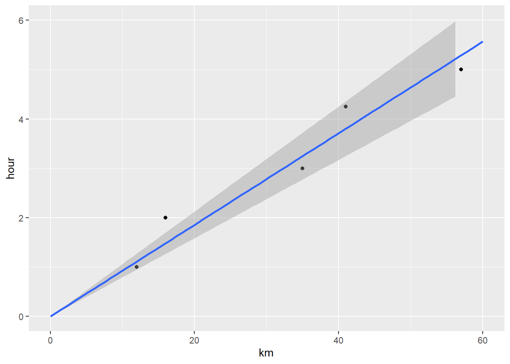

```r
# model1 <- lm( dt$km  ~  dt$hour ); model1

ggplot(dt,  aes(km,hour)) + geom_point( ) + geom_smooth(method = "lm", formula = y ~ 0 + x, fullrange=TRUE) +
  xlim(0,60) + ylim(0,6)
```

This gives us $V_{ave} = 10.7$

What did you notice? - The result is different!

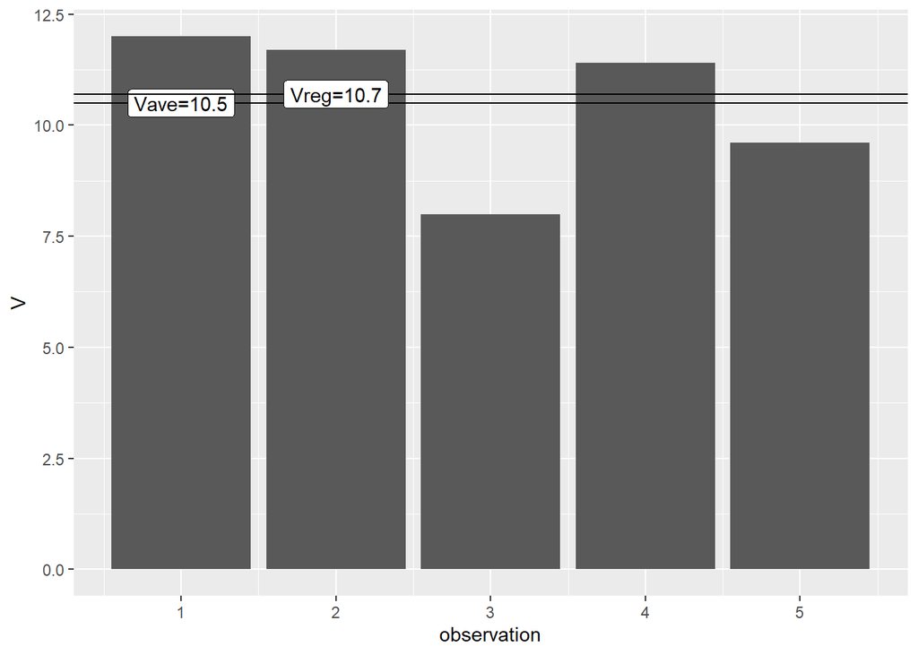

```r
dt[, observation:=1:.N]
ggplot(dt) + geom_col( aes(observation,V) ) +
  geom_hline(yintercept = V.ave1) +
  geom_label(aes(1,V.ave1, label=paste0("Vave=", V.ave1))) +
  geom_hline(yintercept = V.as_pente) +
  geom_label(aes(2,V.as_pente, label=paste0("Vreg=", V.as_pente)))
```

Let's understand what's going on.

Let's add FIVE "new" points, which are actually not new, but are the first one repeated FIVE more times, and see what changes.

```r
dt <- dt %>% rbind( dt[1]);
dt <- dt %>% rbind( dt[1])
dt <- dt %>% rbind( dt[1])
dt <- dt %>% rbind( dt[1])
dt <- dt %>% rbind( dt[1])

V.ave1 = mean(dt$V) %>% round(1); V.ave1
```

```
## [1] 11.3
```

```r
V.sd1 = sd(dt$V) %>% round(1); V.sd1
```

```
## [1] 1.4
```

```r
dt[, observation:=1:.N]


model1 <- lm( dt$km ~ dt$hour ); model1
```

```
##
## Call:
## lm(formula = dt$km ~ dt$hour)
##
## Coefficients:
## (Intercept)      dt$hour
##      0.8727      10.4826
```

```r
V.as_pente <- model1$coefficients[2] %>% round(1); V.as_pente
```

```
## dt$hour
##    10.5
```

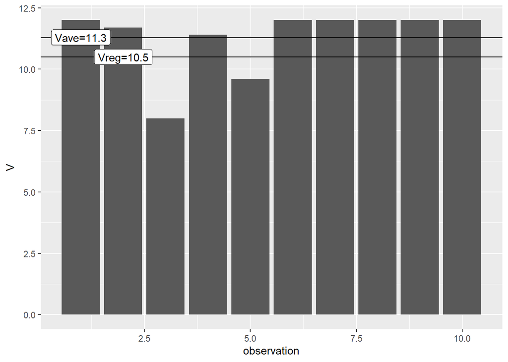

```r
ggplot(dt) + geom_col( aes(observation,V) ) +
  geom_hline(yintercept = V.ave1) +
  geom_label(aes(1,V.ave1, label=paste0("Vave=", V.ave1))) +
  geom_hline(yintercept = V.as_pente) +
  geom_label(aes(2,V.as_pente, label=paste0("Vreg=", V.as_pente)))
```

So now you know it. However you may still wonder about two things:

1. What is actually computer doing in this intimidatingly sounding proccess called "regression"?, and
2. What if you don't have computer? How then should you compute the average speed that would be most meaningful for the process?

## Example 2: projectile

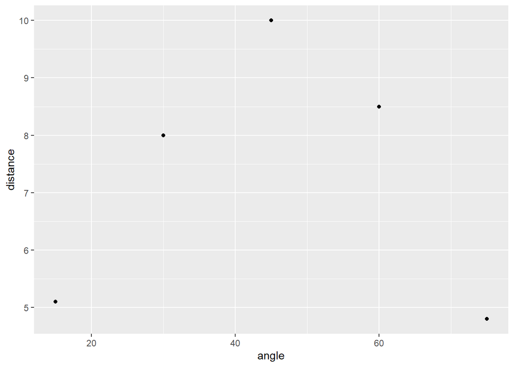

```r
#if numbers are entered later (e.g. as input from user),
projectile <- data.table()
projectile$angle<- c(15, 30, 45, 60, 75)
projectile$distance <- c(5.1, 8, 10,  8.5, 4.8)
projectile <- setDT(setDF(projectile))

projectile$sin2b <- sin( 2* projectile$angle / 180 * pi)

g <- 9.8
projectile$V0 <- sqrt (g*projectile$distance /  projectile$sin2b)



# OR ggplot() + geom_point( aes(projectile$angle, projectile$distance)  )
# OR ggplot(projectile, aes(projectile$angle, projectile$distance) ) + geom_point()
ggplot(projectile) +geom_point( aes(angle,distance) )
```

```r
projectile
```

```
##    angle distance     sin2b       V0
## 1:    15      5.1 0.5000000 9.998000
## 2:    30      8.0 0.8660254 9.514648
## 3:    45     10.0 1.0000000 9.899495
## 4:    60      8.5 0.8660254 9.807474
## 5:    75      4.8 0.5000000 9.699485
```

```r
V0.ave <- mean(projectile$V0, na.rm = T); V0.ave
```

```
## [1] 9.78382
```

```r
V0.sd <- sd(projectile$V0, na.rm = T); V0.sd
```

```
## [1] 0.1866677
```

```r
V0.se <- V0.sd /sqrt( length(projectile$distance)); V0.se
```

```
## [1] 0.08348035
```

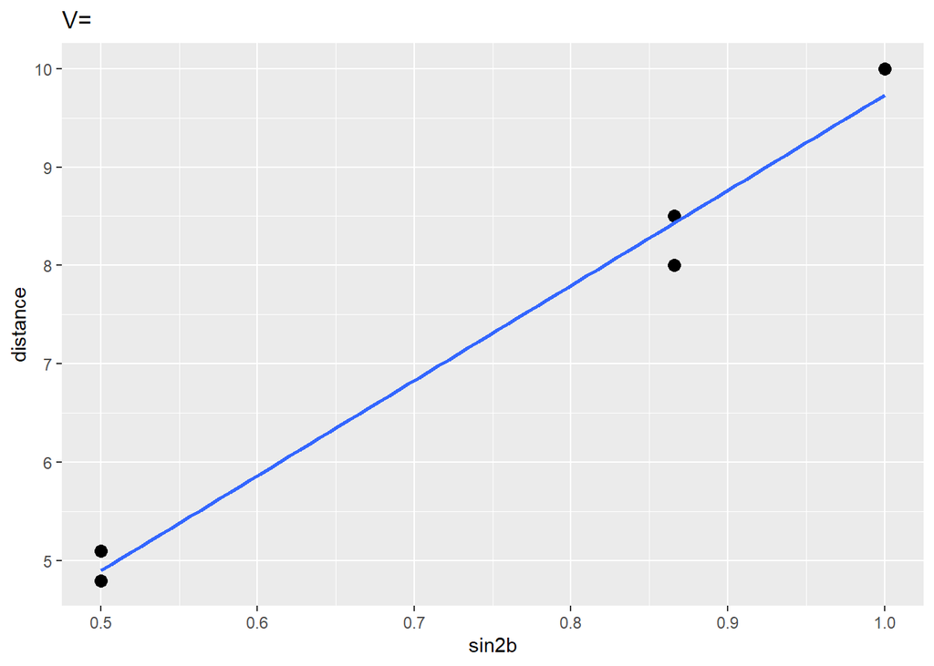

```r
# ORqplot(x=sin2b,y=distance, data=projectile, geom="point")
ggplot(projectile, aes(x=sin2b,y=distance)) +
  geom_point(size=3) +
  geom_smooth(method = "lm", se=F) +
  labs(title="V=")
```

```r
model1 <- lm( projectile$distance ~  projectile$sin2b)
str(model1)
```

[output not shown]

```r
model1$coefficients
```

```
##      (Intercept) projectile$sin2b
##       0.07184394       9.65709798
```

```r
str(model1$coefficients)
```

```
##  Named num [1:2] 0.0718 9.6571
##  - attr(*, "names")= chr [1:2] "(Intercept)" "projectile$sin2b"
```

```r
V0.as_pente <- model1$coefficients[2]; V0.as_pente
```

```
## projectile$sin2b
##         9.657098
```